# Exploring Iowa Hawkeye Basketball

### Introduction

Data for this project covers 5 seasons of Hawkeyes Men’s basketball, from the 2012-13 through 2016-17 seasons. The data can be found here:

https://console.cloud.google.com/marketplace/details/ncaa-bb-public/ncaa-basketball?pli=1

The SQL queries on Google’s service were fairly straightforward. Data was pulled from two tables: one focused on game-level information, and the other on play-by-play data. Results were filtered to games/plays involving the Hawkeyes and imported to R.

### Querying and Cleaning the Data

### Home vs Away

How did the Hawkeyes fare at Carver-Hawkeye Arena compared to when they travelled?

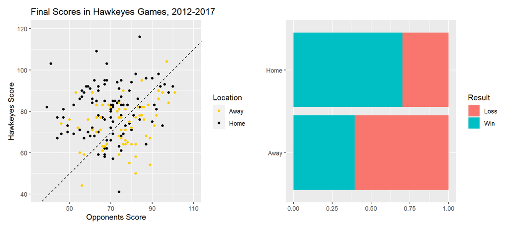

The left plot above illustrates final scores in Hawkeye games. The dotted line represents a tie score. Points to the top left of this line indicate a Hawkeye win, and bottom right points represent losses. It’s evident that Iowa wins a much higher proportion of home games than away games. This is made even clearer with the adjacent chart.

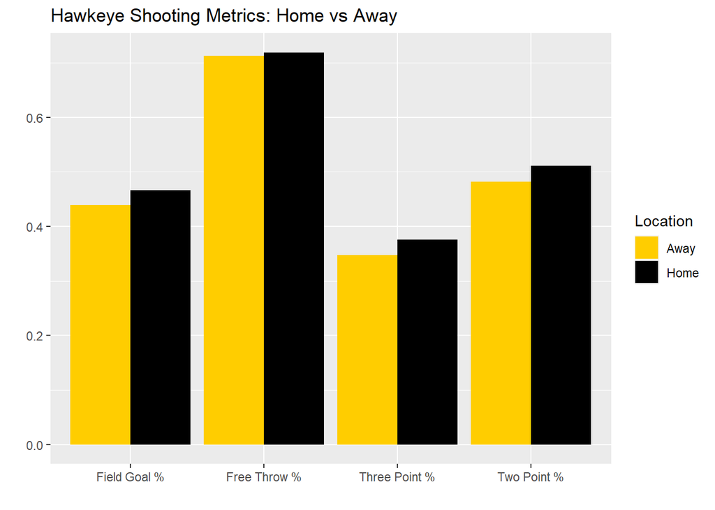

The chart above shows a major contributing factor to the Hawkeyes better home performance is their shooting – it’s improved across the board.

### Conference Comparisons

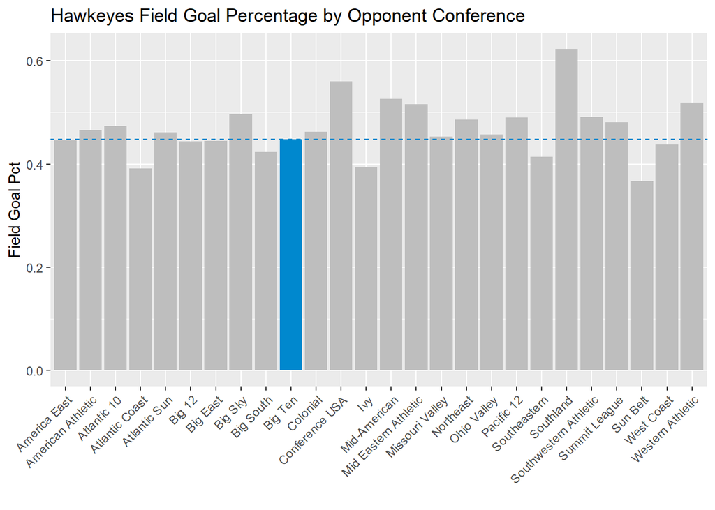

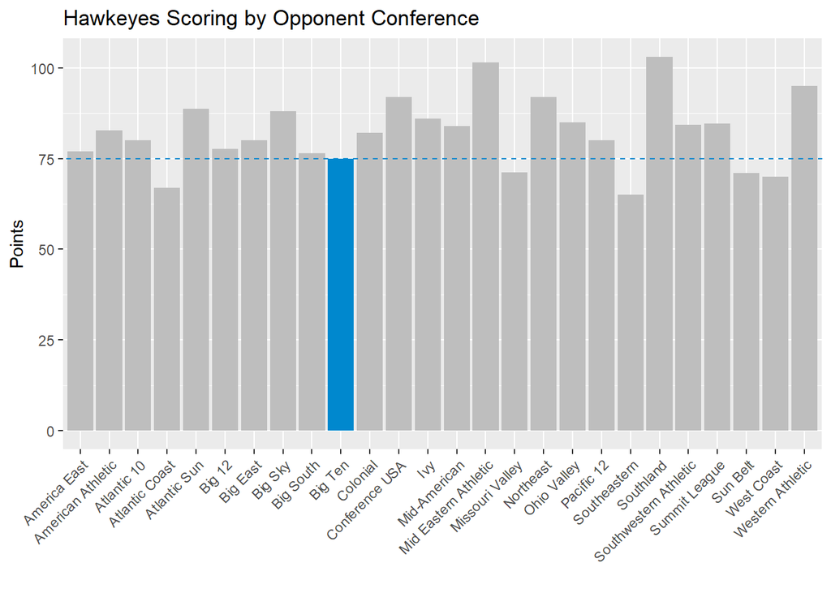

Breaking down these same results by conference teams, we can see that the Hawkeyes were fairly consistent in terms of field goal percentage, and more variable when is came to scoring. Interestingly, despite shooting the most effectively against Michigan, the Hawkeyes scored the third least points on average against them. This suggests factors beyond shooting (like rebounding and turnovers) can also have a significant impact on scoring, which is to be expected.

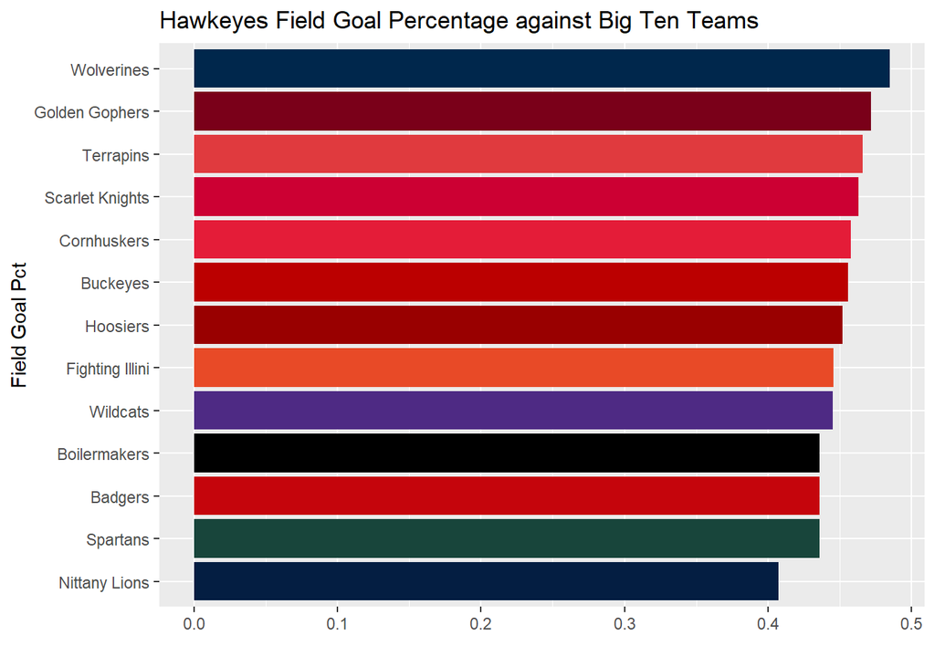

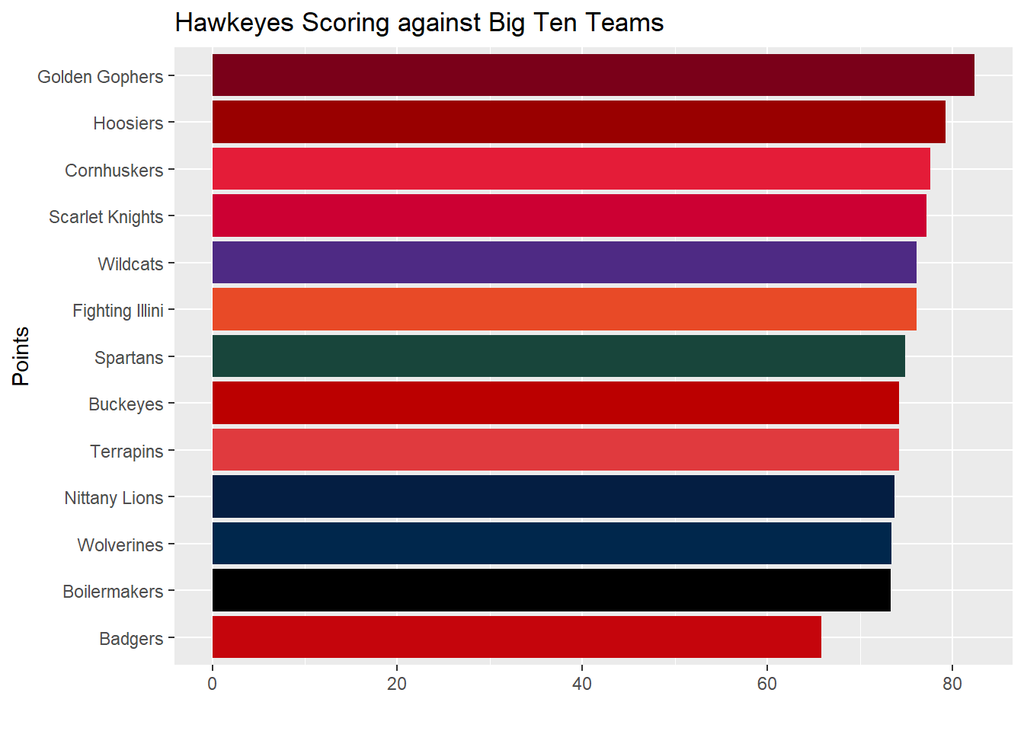

### Shooting Distances

Shooting three point shots has become increasingly common over the past decade. Do we see this trend over the 5 season span in this dataset?

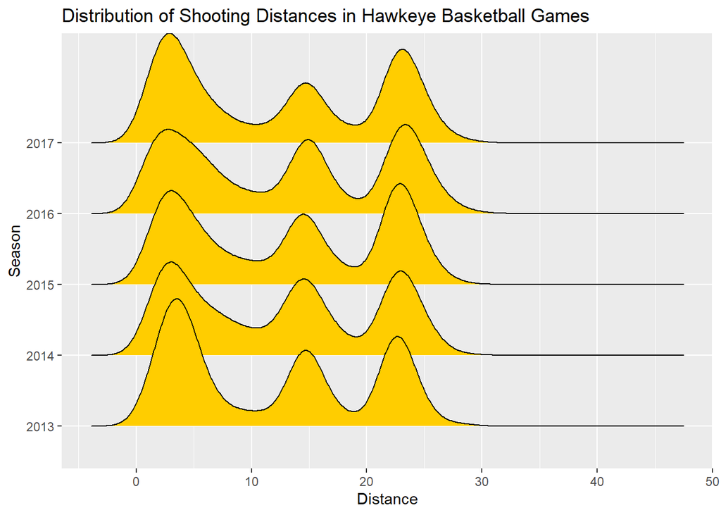

The ridge plots above show the distribution of distances shots were taken from. There are three modes in the distribution: near the basket, at the free throw line, and just beyond the three-point arc. These distributions look very similar, so it doesn’t appear shooting habits changed much over the timeframe.

### Shot locations

Shot location data can (eventually) be plotted on this court graphic.

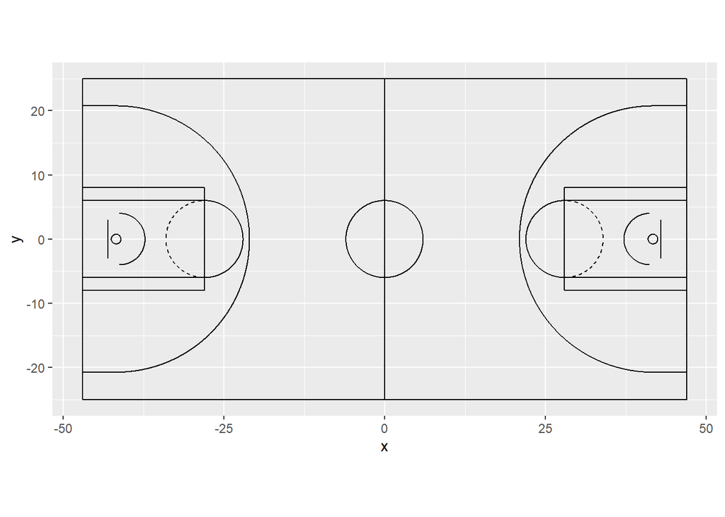